# Assignment 1 Data Wrangling

Yaniv Bronshtein

1/31/2021

## Import the libraries

```r
library(babynames)
library(tidyverse)
```

## Plot the number of male and female babies named Taylor *by year*

**Filter the babynames dataset for the name Taylor**

**Create a ggplot using the newly filtered data where the x-axis is the year,** **y-axis is the count of the number of babies, and the color of each line is** **defined by the sex variable**

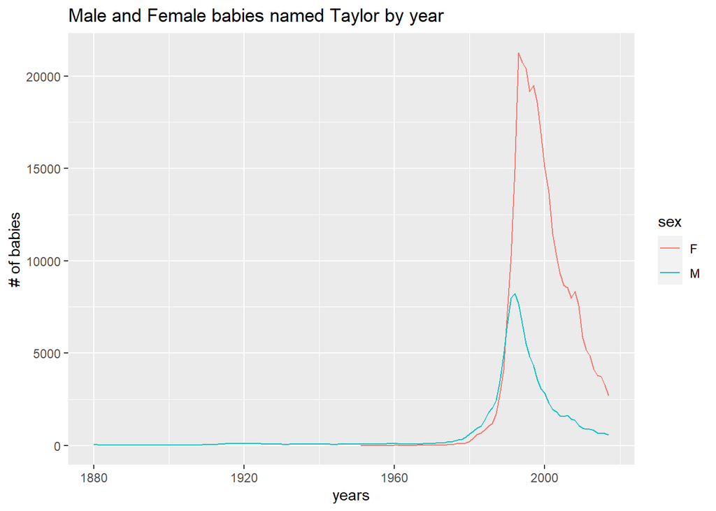

# Answer the following questions, showing plots to substantiate your answers:

## 1. Is a 16 year old named Quinn more likely to be a boy or a girl?

**Initialize the variables for the scale**

```r
max_year <- max(babynames$year)
year_16 <- max_year - 16
```

**Filter the babynames data set for the name Quinn, and the year is 2001 onward**

```r
baby_Quinn = filter(babynames, name=="Quinn", year>= year_16)
```

**Create a ggplot using the newly filtered data where the x-axis is the year,** **y-axis is the count of the number of babies, and the color of each line is** **defined by the sex variable. The scale is set at 2 year increments starting** **2001 and ending 2017**

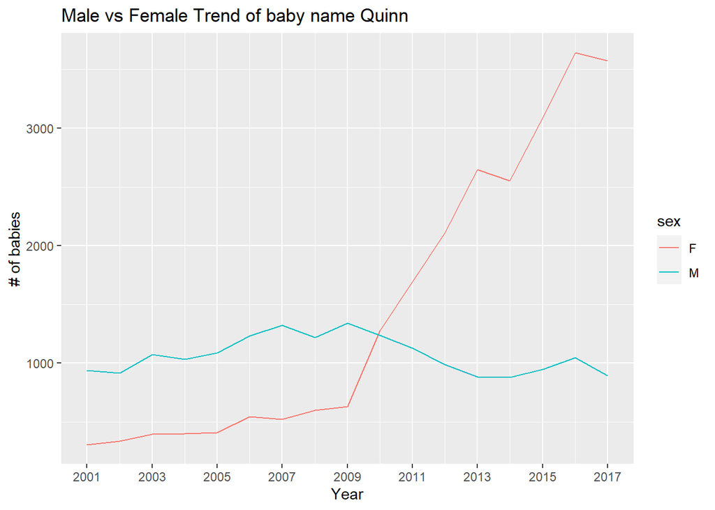

```r
ggplot(data = baby_Quinn) +
  geom_line(mapping=aes(x=year, y=n, color=sex)) +
  labs(title = "Male vs Female Trend of baby name Quinn",
       x = "Year",
       y = "# of babies") +
  scale_x_continuous(breaks = seq(year_16, max_year, by = 2))
```

*According to the plot above, a 16 year old named Quinn was born in 2001 since* *the data set ends in 2017. Even if one were to consider the current year to be* *2021(which would mean Quinn was born in 2005,Quinn was still mostly a boy’s name.)*

### 2. Is a 2 year old named Quinn more likely to be a boy or a girl?

*According to the plot above, a 2 year named Quinn would have been born in 2015.* *During this time, Quinn was overwhelmingly a girl’s name. Since the data ends* *in 2017, it is impossible to consider the current year to be 2021 with a baby* *born in 2019.*

### 3. What is your best guess as to how old a woman named Susan is?

```r
susan_female <- filter(babynames, name=="Susan", sex == "F")
```

**Create a ggplot using the newly filtered data where the x-axis is the year,** **y-axis is the count of the number of babies**

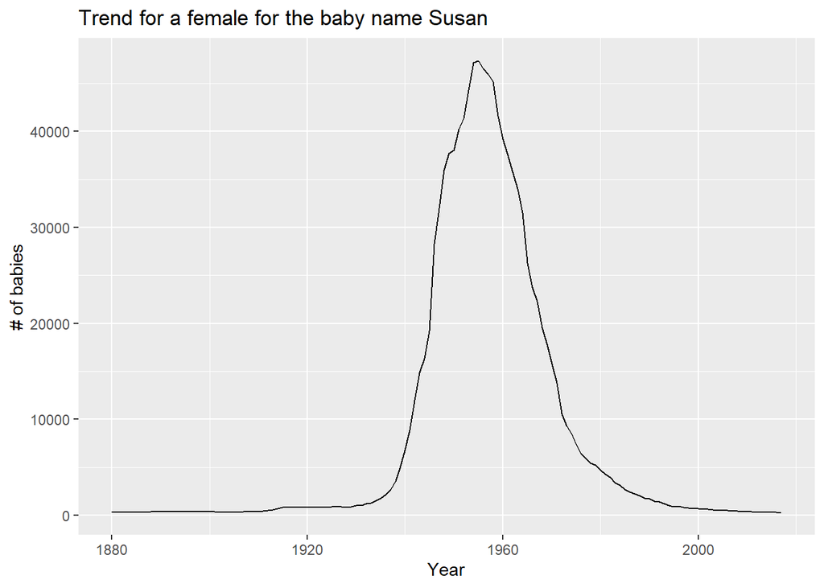

```r
ggplot(data = susan_female) +
  geom_line(mapping=aes(x=year, y=n)) +
  labs(title = "Trend for a female for the baby name Susan",
       x = "Year",
       y = "# of babies")
```

*According to the plot above, the popularity of the baby name Susan can be* *approximated by the normal distribution with a peak popularity between 1950* *and 1960. If one takes 2017 to be the final year, that would put our Susan* *at between 57 and 67. I believe the question to be ambiguous as even in 1980* *there are roughly 5000 Susans born. For all we know, there was an attack on* *the Susans born between 1950 and 1960 and the only Susans left were born in* *1980 making them 37 years old.*